# bayes_exploration

## Introduction

This project explores weekly matchup data from my fantasy baseball league for the 2011-2019 seasons.  
Parts of this analysis are motivated by [Peadar Coyle's](https://docs.pymc.io/pymc-examples/examples/case_studies/rugby_analytics.html) Rugby Analysis case study, and [PyMC3's GLM: Logistic Regression](https://docs.pymc.io/pymc-examples/examples/generalized_linear_models/GLM-logistic.html) example.

The data was collected using the [Yahoo Fantasy Baseball](https://developer.yahoo.com/fantasysports/guide/) API and is available in the `full_data.csv` file.

The league consists of 14 teams and each season usually consists of 21 weekly matchups.  
Scoring is based on 18 statistical categories. Weekly "scores" are based on the head-to-head matchup in each category. Category wins, losses and ties are compiled each week and throughout the season to determine the league standings.

> **Batting**: `b_BB`: Walks; `b_HR`: Home Runs; `b_K`: Strikeouts; `b_NSB`: Net Stolen Bases; `b_R`: Runs; `b_RBI`: Runs Batted In.  
> **Pitching**: `p_BB`: Walks; `p_IP`: Innings Pitched; `p_K`: Strikeouts; `p_L`: Losses; `p_NSVH`: Net Saves and Holds; `p_QS`: Quality Starts; `p_W`: Wins.

The rest are rate categories:

> **Batting**: `b_AVGr`: Batting Average; `b_OBPr`: On-Base Percentage; `b_SLGr`: Slugging Percentage.  
> **Pitching**: `p_ERAr`: Earned-run Average; `p_WHIPr`: Walks plus Hits per Innings Pitched.

As noted above, the season standings are not influenced by the overall weekly winner, and consist of an aggregate score. For example, in a weekly matchup of two teams, the result is not purely a win or a loss. The "winning" team might win 10 categories, lose six and tie two, and the "score" of 10-6-2 is simply added to their standings.

Despite this, Yahoo's API includes a "weekly winning team" category, and for the sake of exploring the data and Bayesian approaches, the concept of a team winning the weekly matchup will be used to develop exploratory models.

## Motivation

Ideally, this analysis could be used to infer a parameter or a threshold that would lead to more wins in each category. One thought was to identify key categories to focus on and develop a predictive model for weekly matchup wins based on individual categories. However, I found that the variances in the data and the large number of categories meant that each category has a relatively small individual impact on the overall weekly likelihood of a "win".

Likewise, as we'll see below, the data is highly-correlated in ways that make sense: a hit results in an increase in batting average, on-base percentage, and slugging percentage; a home run results in an increase in home runs, runs, runs batted in, slugging percentage, and on-base percentage.

As such, this analysis aims to explore the data and the Bayesian logistic regression toolset in the `PyMC3` library, and to make general observations about the data and how the models could be used or fine-tuned.

Lastly, I should note that the high-dimensionality in the data meant that attempts to elicit priors were ineffective, and sometimes caused errors in the computations. Based on experiences this semester in OpenBugs in which we defined uninformative priors, I felt it was a good idea to defer to [PyMC3's defaults for generalized linear models](https://docs.pymc.io/api/glm.html#module-pymc3.glm.linear), which are a Flat, uninformative prior distribution for the intercept, and a Normal distribution with mean=0 and precision=1.0E-6 for all regressors.

### Library Imports

```python
# Plotting functions
import matplotlib as mpl
import matplotlib.pyplot as plt
import matplotlib.cm as cm
import seaborn as sns

# Data-handling
import numpy as np
import pandas as pd

# Modeling
from sklearn.preprocessing import StandardScaler
from sklearn.linear_model import LogisticRegression
from sklearn.pipeline import make_pipeline
from sklearn.preprocessing import RobustScaler
from sklearn.preprocessing import QuantileTransformer
from sklearn.metrics import classification_report
from sklearn.metrics import confusion_matrix
from sklearn.metrics import r2_score
from sklearn.metrics import roc_auc_score
from sklearn.naive_bayes import GaussianNB
from sklearn.svm import LinearSVC
from sklearn.model_selection import train_test_split
from sklearn.feature_selection import SelectPercentile, f_classif
import theano.tensor as tt
import pymc3 as pm
import arviz as az

# Utilities
import os
import warnings
warnings.filterwarnings("ignore")
from time import time
import pickle
from pathlib import Path

%matplotlib inline
mpl.style.use('ggplot')
```

### Data Import and Analysis

```python
try:
    from league.config import DATA_DIRECTORY, LEAGUE_DATA_DIRECTORY
    league_directory = LEAGUE_DATA_DIRECTORY
    data_directory = DATA_DIRECTORY
    data = pd.read_csv(os.path.join(data_directory, "full_data.csv"))
except FileNotFoundError:
    data = pd.read_csv("./full_data.csv")

data.sample(3)
```

|  | season | week | n_days | team_id | category | value | won_category | won_week | id |
| --- | --- | --- | --- | --- | --- | --- | --- | --- | --- |
| 44907 | 2019 | 14 | 7 | 14 | b_AVGr | 0.284 | 1.0 | True | 2019_14_14 |
| 35660 | 2017 | 24 | 7 | 9 | p_W | 6.000 | 0.0 | False | 2017_24_9 |
| 20664 | 2015 | 5 | 7 | 6 | b_RBI | 28.000 | 0.0 | False | 2015_5_6 |

```python
data.isnull().sum()/len(data)
```

```
season          0.000000
week            0.000000
n_days          0.000000
team_id         0.000000
category        0.000000
value           0.000000
won_category    0.006439
won_week        0.000000
id              0.000000
dtype: float64
```

A small number of the won_category values are ties, and as such are missing values. Since tied categories don't contribute to whether a team won or lost the week, I'll set them to zero. Though for individual category predictions, it may be interesting to classify them separately in the future.

```python
data['won_category'] = data['won_category'].fillna(0)
```

#### Category analysis

In order to look at modeling individual categories, I'm going to pivot the data rather than filter by `category` and `won_category`. This will be useful when looking at modeling weekly wins, too.

```python
data_pivot = data.pivot(index=['id'], columns='category', values = 'value')
data_pivot['won_week'] = data.groupby('id')['won_week'].mean()
won_week = 1 * (data_pivot['won_week'] == True)
data_pivot['won_week'] = won_week
data_pivot.sample(3, random_state=2)
```

| category id | b_AVGr | b_BB | b_HR | b_K | b_NSB | b_OBPr | b_R | b_RBI | b_SLGr | p_BB | p_ERAr | p_IP | p_K | p_L | p_NSVH | p_QS | p_W | p_WHIPr | won_week |
| --- | --- | --- | --- | --- | --- | --- | --- | --- | --- | --- | --- | --- | --- | --- | --- | --- | --- | --- | --- |
| 2015_7_14 | 0.209 | 19.0 | 7.0 | 40.0 | 4.0 | NaN | 26.0 | 26.0 | NaN | 12.0 | 4.25 | 42.333333 | 43.0 | 3.0 | 2.0 | NaN | 3.0 | 1.32 | 0 |
| 2019_17_5 | 0.224 | 29.0 | 10.0 | 64.0 | 1.0 | 0.312 | 34.0 | 22.0 | 0.386 | 31.0 | 5.02 | 61.000000 | 57.0 | 4.0 | 3.0 | 5.0 | 3.0 | 1.46 | 0 |
| 2017_20_6 | 0.189 | 23.0 | 11.0 | 60.0 | 1.0 | 0.274 | 27.0 | 28.0 | 0.413 | 14.0 | 5.40 | 51.666667 | 48.0 | 6.0 | 3.0 | 4.0 | 2.0 | 1.37 | 0 |

The wider dataset will be a bit easier to select by column. I can also already see some `NaN` values in the category values, which are a result of some categories not being counted by the league in certain years.

I'm also going to split the pivoted data into two datasets for analysis: counting and rate categories.

```python
counting_categories = [c for c in data_pivot.columns if not 'r' in c]
rate_categories = [c for c in data_pivot.columns if 'r' in c]
df_count = data_pivot[counting_categories]
df_rate = data_pivot[rate_categories]

# Add back the won_week column
df_rate['won_week'] = data_pivot['won_week']
```

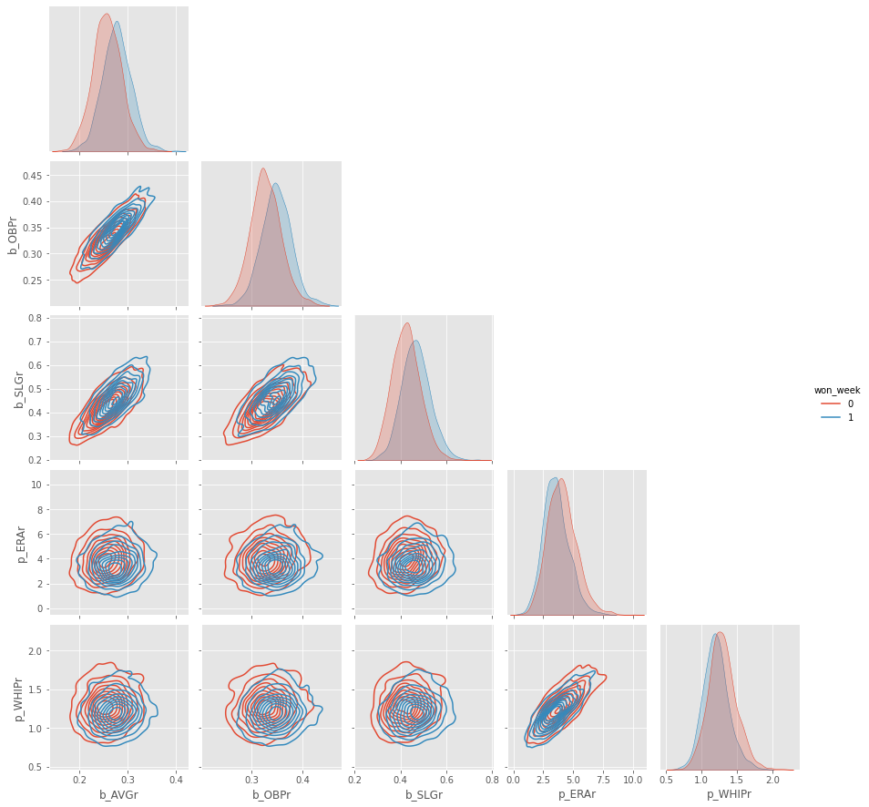

```python
sns.pairplot(df_rate, kind = 'kde', hue='won_week', corner=True)
```

The KDE plot shows a pretty normal distribution with some long tails here and there. Some of the inputs are clearly going to be correlated. These may need to be removed when modeling weekly wins.

```python
batting_categories = [c for c in df_count.columns if 'b_' in c]
pitching_categories = [c for c in df_count.columns if 'p_' in c]
```

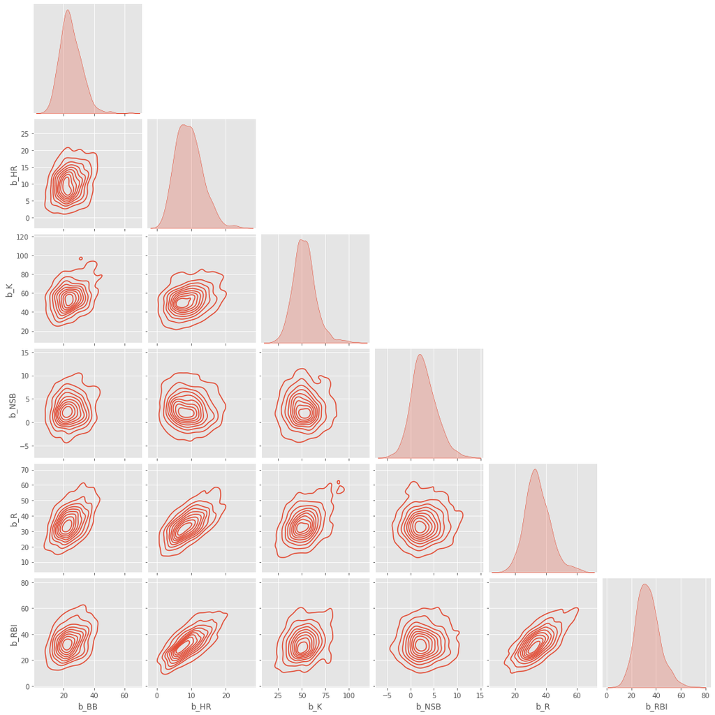

```python
sns.pairplot(df_count[batting_categories].sample(1000, random_state=42), kind = 'kde', corner=True)
```

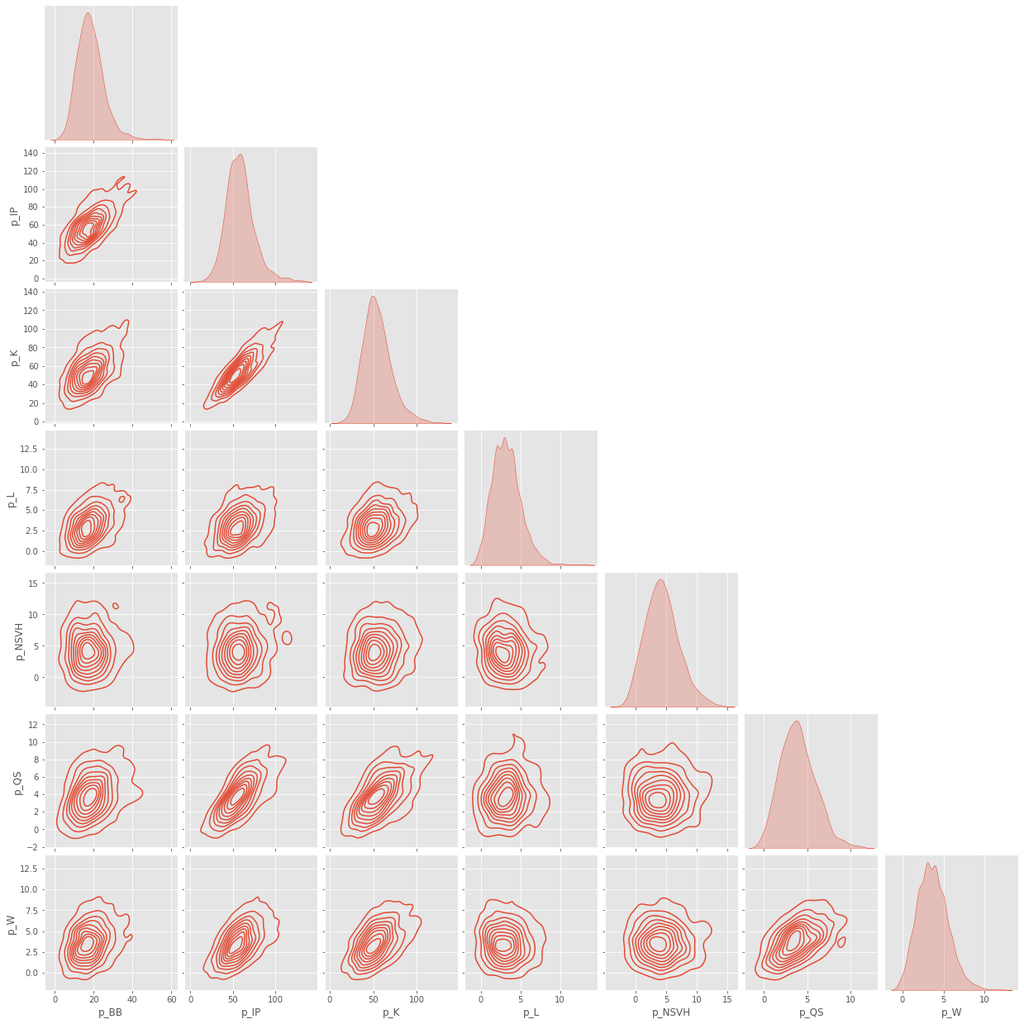

```python
sns.pairplot(df_count[pitching_categories].sample(1000, random_state=42), kind = 'kde', corner=True)
```

Check correlations to explore categories to model

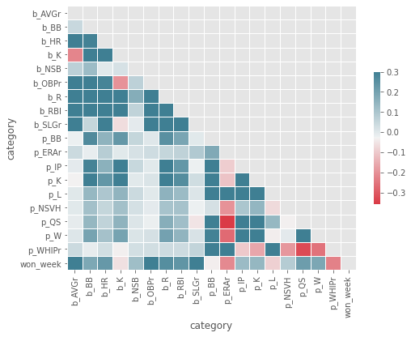

```python
corr = data_pivot.corr()
mask = np.zeros_like(corr, dtype=np.bool_)
mask[np.triu_indices_from(mask)] = True
f, ax = plt.subplots(figsize=(8, 6))
cmap = sns.diverging_palette(10, 220, as_cmap=True)
sns.heatmap(corr, mask=mask, cmap=cmap, vmax=0.3, linewidths=0.5, cbar_kws={"shrink": 0.5}, ax=ax)
```

```python
np.absolute(corr['won_week']).sort_values(ascending=False)
```

```
category
won_week    1.000000
b_OBPr      0.330327
b_SLGr      0.326295
b_AVGr      0.317197
b_R         0.258492
b_RBI       0.238474
p_WHIPr     0.229167
b_HR        0.226006
p_ERAr      0.213816
p_QS        0.213438
p_W         0.185446
b_BB        0.184440
p_K         0.140779
p_IP        0.130714
b_NSB       0.121273
p_L         0.086933
p_NSVH      0.081033
b_K         0.059486
p_BB        0.036476
Name: won_week, dtype: float64
```

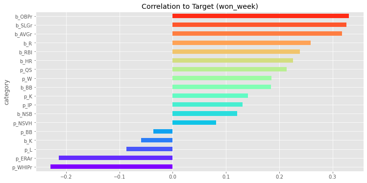

```python
n_fts = len(data_pivot.columns)
colors = cm.rainbow(np.linspace(0, 1, n_fts))

data_pivot.drop(
    'won_week', axis=1).corrwith(
    data_pivot.won_week).sort_values(
    ascending=True).plot(
    kind='barh', color=colors,figsize=(12,6))

plt.title("Correlation to Target (won_week)")
plt.show()
```

Based on an arbitrary assessment of these I think we can drop `p_L`, `p_NSVH`, `b_K` and `p_BB` as fairly irrelevant features.

```python
features_to_drop = ['p_L', 'p_NSVH', 'b_K', 'p_BB']
df = data[~data['category'].isin(features_to_drop)].reset_index()
df_pivot = data_pivot.drop(features_to_drop, axis=1)
```

Split the data for training and testing

```python
y = df_pivot['won_week']
df_pivot = df_pivot.drop(['won_week'], axis=1)

df_pivot.isna().sum()
```

```
category
b_AVGr        0
b_BB       1272
b_HR          0
b_NSB         0
b_OBPr      318
b_R           0
b_RBI         0
b_SLGr      318
p_ERAr        0
p_IP          0
p_K           0
p_QS       1590
p_W           0
p_WHIPr       0
dtype: int64
```

```python
df_pivot['b_BB'] = df_pivot['b_BB'].interpolate(limit_direction='backward')
df_pivot['b_OBPr'] = df_pivot['b_OBPr'].interpolate(limit_direction='backward')
df_pivot['b_SLGr'] = df_pivot['b_SLGr'].interpolate(limit_direction='backward')
df_pivot['p_QS'] = df_pivot['p_QS'].interpolate(limit_direction='backward')

df_pivot.isna().sum()
```

```
category
b_AVGr     0
b_BB       0
b_HR       0
b_NSB      0
b_OBPr     0
b_R        0
b_RBI      0
b_SLGr     0
p_ERAr     0
p_IP       0
p_K        0
p_QS       0
p_W        0
p_WHIPr    0
dtype: int64
```

```python
dataset_path = Path('datasets')
for p in [dataset_path]:
    if not p.exists():
        p.mkdir()

with open(dataset_path / 'df_pivot.pkl', 'wb') as buff:
    pickle.dump({'X_pivot': df_pivot, 'y_pivot': y}, buff)

with open(dataset_path / 'df.pkl', 'wb') as buff:
    pickle.dump(df, buff)

X_train, X_test, y_train, y_test = train_test_split(df_pivot, y, test_size=.3, random_state=42)

with open(dataset_path / 'test_train.pkl', 'wb') as buff:
    pickle.dump({'X_train': X_train, 'X_test': X_test, 'y_train': y_train, 'y_test': y_test}, buff)
```

# Models

### Full set - Sklearn models

```python
# Pipelines
max_iterations = np.ceil(10**6/X_train.shape[0])

scalers = {
    'Standard': StandardScaler(),
    'Robust': RobustScaler(quantile_range=(25,75)),
    'Gaussian': QuantileTransformer(output_distribution='normal')
}

classifiers = {
    'LogisticRegression': LogisticRegression(max_iter=max_iterations,
                                            n_jobs=-1,
                                            random_state=42),
    'Gaussian': GaussianNB()

}

for i, (clf, classifier) in enumerate(classifiers.items()):
    for name, scaler in scalers.items():
        pipe = make_pipeline(scalers[name], classifier)
        print("=" * 80)
        t0 = time()
        print(f"Fitting {clf} with {name} scaling")
        pipe.fit(X_train, y_train)
        y_pred = pipe.predict(X_test)
        t1 = time() - t0
        print(f'Fitting took {t1} seconds')
        print("-" * 80)
        print()
        print(confusion_matrix(y_test, y_pred))
        print(classification_report(y_test, y_pred))
        print("Number of mislabeled points out of a total %d points : %d" % (X_test.shape[0], (y_test != y_pred).sum()))
        print(f'Score: {pipe[-1].score(X_test, y_test)}')
        try:
            print(f'Coefficients: {pipe[-1].coef_}')
        except AttributeError:
            pass
        print()
```

```
================================================================================
Fitting LogisticRegression with Standard scaling
Fitting took 2.1360080242156982 seconds
--------------------------------------------------------------------------------

[[330 146]
 [136 281]]
              precision    recall  f1-score   support

           0       0.71      0.69      0.70       476
           1       0.66      0.67      0.67       417

    accuracy                           0.68       893
   macro avg       0.68      0.68      0.68       893
weighted avg       0.68      0.68      0.68       893

Number of mislabeled points out of a total 893 points : 282
Score: 0.4669652855543113
Coefficients: [[ 0.35984695  0.0858071   0.13312591  0.22244607  0.29344733  0.08882741
   0.03209852  0.24307337 -0.19632874  0.11442263 -0.02887092  0.18483869
   0.17497532 -0.40391146]]

================================================================================
Fitting LogisticRegression with Robust scaling
Fitting took 0.03325486183166504 seconds
--------------------------------------------------------------------------------

[[330 146]
 [137 280]]
              precision    recall  f1-score   support

           0       0.71      0.69      0.70       476
           1       0.66      0.67      0.66       417

    accuracy                           0.68       893
   macro avg       0.68      0.68      0.68       893
weighted avg       0.68      0.68      0.68       893

Number of mislabeled points out of a total 893 points : 283
Score: 0.4669652855543113
```

[output cut: 67 more lines]

```
--------------------------------------------------------------------------------

[[304 172]
 [118 299]]
              precision    recall  f1-score   support

           0       0.72      0.64      0.68       476
           1       0.63      0.72      0.67       417

    accuracy                           0.68       893
   macro avg       0.68      0.68      0.68       893
weighted avg       0.68      0.68      0.68       893

Number of mislabeled points out of a total 893 points : 290
Score: 0.5330347144456887
```

### Feature Selection

```python
anova_filter = SelectPercentile(f_classif, 60)
clf = LinearSVC(random_state=42)
anova_svm = make_pipeline(anova_filter, clf)
anova_svm.fit(X_train, y_train)
y_pred = anova_svm.predict(X_test)
print(classification_report(y_test, y_pred))
print(confusion_matrix(y_test, y_pred))
print("Number of mislabeled points out of a total %d points : %d" % (X_test.shape[0], (y_test != y_pred).sum()))
```

```
              precision    recall  f1-score   support

           0       0.73      0.62      0.67       476
           1       0.63      0.75      0.68       417

    accuracy                           0.68       893
   macro avg       0.68      0.68      0.68       893
weighted avg       0.69      0.68      0.68       893

[[294 182]
 [106 311]]
Number of mislabeled points out of a total 893 points : 288
```

```python
anova_svm[-1].coef_
```

```
array([[ 2.03211612e+00,  1.22243124e-02,  2.12391972e+00,
         1.27539915e-03,  2.18969215e-02,  2.06821681e+00,
        -1.01776179e-01, -9.40980677e-01]])
```

```python
features = anova_svm[:-1].inverse_transform(anova_svm[-1].coef_)
anova_coef = pd.DataFrame(features, columns = X_train.columns.values)
anova_coef
```

|  | b_AVGr | b_BB | b_HR | b_NSB | b_OBPr | b_R | b_RBI | b_SLGr | p_ERAr | p_IP | p_K | p_QS | p_W | p_WHIPr |
| --- | --- | --- | --- | --- | --- | --- | --- | --- | --- | --- | --- | --- | --- | --- |
| 0 | 2.032116 | 0.0 | 0.012224 | 0.0 | 2.12392 | 0.001275 | 0.021897 | 2.068217 | -0.101776 | 0.0 | 0.0 | 0.0 | 0.0 | -0.940981 |

```python
week = np.array([[.258, 18, 12, 0, .333, 36, 21, .532, 6.48, 37.1, 18, 1, 1, 1.8]])
anova_svm.predict(week)
```

```
array([0])
```

TODO: Enter back into Sklearn models with the features selected

```python
all = 'won_week ~ b_AVGr + b_BB + b_HR + b_NSB + b_OBPr + b_R + b_RBI + b_SLGr + p_ERAr + p_IP + p_K + p_QS + p_W + p_WHIPr'
some = 'won_week ~ b_AVGr + b_HR + b_OBPr + b_R + b_RBI + b_SLGr + p_ERAr + p_WHIPr'

with pm.Model() as full_model:
    pm.glm.GLM.from_formula(
        all, df_pivot, family=pm.glm.families.Binomial()
    )
```

```python
with full_model:
    trace_full = pm.sample(tune=1000,
                     draws=1000,
                     chains=4,
                     init = 'adapt_diag',
                     cores=2)

az.summary(trace_full, round_to=3)
```

[output not shown]

```python
model_path = Path('models')
for p in [model_path]:
    if not p.exists():
        p.mkdir()
```

```python
model_path = Path('models')
for p in [model_path]:
    if not p.exists():
        p.mkdir()

with open(model_path / 'full_model.pkl', 'wb') as buff:
    pickle.dump({'model': full_model, 'trace': trace_full}, buff)
```

```python
with open(model_path / 'full_model.pkl', 'rb') as buff:
    data0 = pickle.load(buff)

full_model, trace_full = data0['model'], data0['trace']
```

[output not shown]

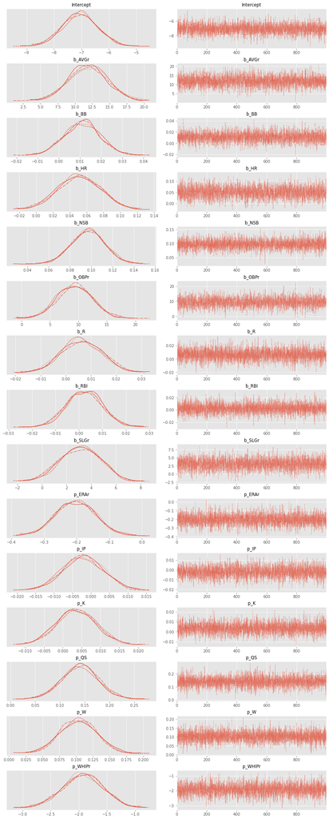

```python
az.plot_trace(trace_full)
```

#### Convergence

```python
draws = 10000

trace_df = pm.trace_to_dataframe(trace_full).iloc[200:].reset_index(drop=True).assign(chain=lambda x: x.index / draws)

trace_df = trace_df.assign(samples=10000)
```

```python
trace_df_long = pd.melt(trace_df, id_vars=['samples', 'chain'])
trace_df_long.info()
```

```
<class 'pandas.core.frame.DataFrame'>
RangeIndex: 57000 entries, 0 to 56999
Data columns (total 4 columns):
 #   Column    Non-Null Count  Dtype
---  ------    --------------  -----
 0   samples   57000 non-null  int64
 1   chain     57000 non-null  float64
 2   variable  57000 non-null  object
 3   value     57000 non-null  float64
dtypes: float64(2), int64(1), object(1)
memory usage: 1.7+ MB
```

```python
g = sns.FacetGrid(trace_df_long, col='variable', row='samples',
                  hue='chain', sharex='col', sharey=False)
g = g.map(sns.distplot, 'value', hist=False, rug=False)
```

[output not shown]

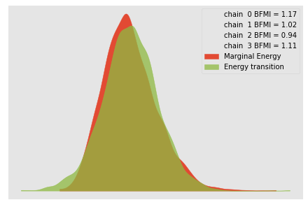

```python
az.plot_energy(trace_full)
```

```
array([<AxesSubplot:title={'center':'94.0% HDI'}>], dtype=object)
```

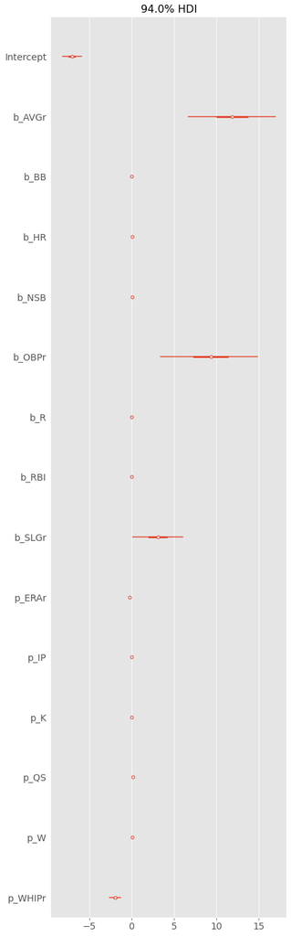

```python
az.plot_forest(trace_full, combined=True)
```

[output not shown]

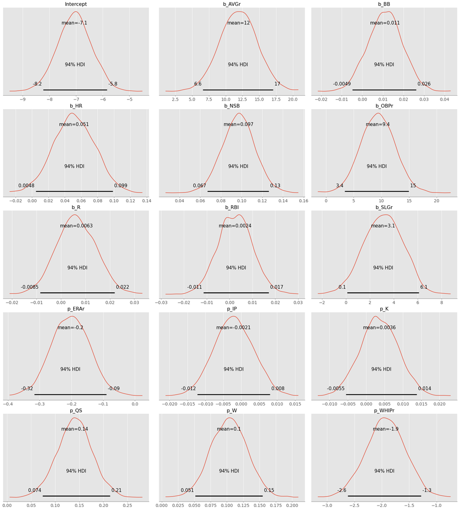

```python
az.plot_posterior(trace_full)
```

### Posterior Predictive Checks

```python
with full_model:
    ppc = pm.sample_posterior_predictive(
        trace_full, samples=500, random_seed=42
    )
```

100.00% [500/500 00:02<00:00]

```python
ppc['y'].shape
```

```
(500, 2974)
```

```python
y_score = np.mean(ppc['y'], axis=0)
```

```python
pred_score = dict(y_true=data_pivot.won_week, y_score = y_score)
```

```python
roc_auc_score(**pred_score)
```

```
0.7735225841587529
```